# Regression_Erin_Kennedy

A00275664

2024-04-01

# Regression Analysis on Bike Rental Demand

### Import the hour dataset and install relevant packages using the **read.csv()** command

```r
bike<-read.csv("~/A00275664/Data/hour.csv", header = T,
               sep = ",", stringsAsFactors = TRUE)
library (tidyverse)
library(caret)
library(DescTools)
library(olsrr)
library(devtools)
library(citr)
library(rbbt)
```

# Preparation

## Initial Analysis

There are no null values in the dataset ensuring cleanliness and comprehensibility.

```r
# Check for missing values
null_values <- colSums(is.na(bike))
print(null_values)
View(bike)
```

[output not shown]

The data types of each variable are appropriate for their respective feature, which enhances the accuracy and reliability of the analysis.

```r
str(bike)
```

```
## 'data.frame':    17379 obs. of  17 variables:
##  $ instant   : int  1 2 3 4 5 6 7 8 9 10 ...
##  $ dteday    : Factor w/ 731 levels "2011-01-01","2011-01-02",..: 1 1 1 1 1 1 1 1 1 1 ...
##  $ season    : int  1 1 1 1 1 1 1 1 1 1 ...
##  $ yr        : int  0 0 0 0 0 0 0 0 0 0 ...
##  $ mnth      : int  1 1 1 1 1 1 1 1 1 1 ...
##  $ hr        : int  0 1 2 3 4 5 6 7 8 9 ...
##  $ holiday   : int  0 0 0 0 0 0 0 0 0 0 ...
##  $ weekday   : int  6 6 6 6 6 6 6 6 6 6 ...
##  $ workingday: int  0 0 0 0 0 0 0 0 0 0 ...
##  $ weathersit: int  1 1 1 1 1 2 1 1 1 1 ...
##  $ temp      : num  0.24 0.22 0.22 0.24 0.24 0.24 0.22 0.2 0.24 0.32 ...
##  $ atemp     : num  0.288 0.273 0.273 0.288 0.288 ...
##  $ hum       : num  0.81 0.8 0.8 0.75 0.75 0.75 0.8 0.86 0.75 0.76 ...
##  $ windspeed : num  0 0 0 0 0 0.0896 0 0 0 0 ...
##  $ casual    : int  3 8 5 3 0 0 2 1 1 8 ...
##  $ registered: int  13 32 27 10 1 1 0 2 7 6 ...
##  $ cnt       : int  16 40 32 13 1 1 2 3 8 14 ...
```

This command provides detailed descriptive statistics for the dataset (*bike*). It provides statistics for each feature such as mean and median. The distribution of the dataset can be revealed from **summary()**.

It can also help when selecting a suitable target and predictor variable and identifying relationships between features within the dataset.

```r
summary(bike)
summary(bike$cnt) # independent variable
```

[output not shown]

The independent variable’s mean is greater than the median which shows that the data is right-skewed

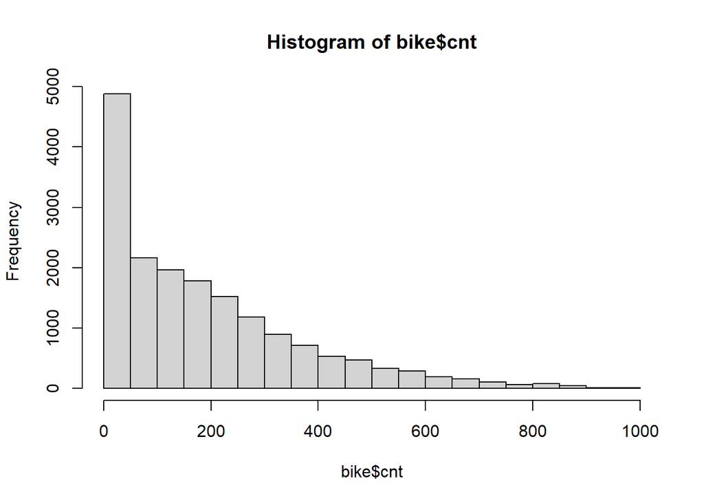

```r
hist(bike$cnt)
```

# Linear Regression Analysis

## Predicting Total Bike Rental Count Based on Dataset Features

The coefficients indicate the estimated average increase or decrease in the count of bikes per hour. The coefficients assume that each predictor variable equals zero and the coefficient value is the predicted value count.

```r
# First regression model
bikemod=lm(formula = cnt ~ season + mnth + weekday + holiday + atemp
           + hum +windspeed + yr + workingday + weathersit +temp,
           data=bike)
bikemod
```

```
##
## Call:
## lm(formula = cnt ~ season + mnth + weekday + holiday + atemp +
##     hum + windspeed + yr + workingday + weathersit + temp, data = bike)
##
## Coefficients:
## (Intercept)       season         mnth      weekday      holiday        atemp
##     78.9211      17.9481       0.8786       1.4821     -21.9204     305.6924
##         hum    windspeed           yr   workingday   weathersit         temp
##   -284.0085      66.4317      77.6769       3.5161       6.6953      50.6362
```

```r
summary(bikemod)
```

```
##
## Call:
## lm(formula = cnt ~ season + mnth + weekday + holiday + atemp +
##     hum + windspeed + yr + workingday + weathersit + temp, data = bike)
##
## Residuals:
##     Min      1Q  Median      3Q     Max
## -361.24  -98.76  -25.08   70.52  646.34
##
## Coefficients:
##              Estimate Std. Error t value Pr(>|t|)
## (Intercept)   78.9211     7.0927  11.127  < 2e-16 ***
## season        17.9481     1.9281   9.309  < 2e-16 ***
## mnth           0.8786     0.6011   1.462 0.143850
## weekday        1.4821     0.5733   2.585 0.009739 **
## holiday      -21.9204     7.0989  -3.088 0.002019 **
## atemp        305.6924    43.9950   6.948 3.83e-12 ***
## hum         -284.0085     7.0380 -40.353  < 2e-16 ***
## windspeed     66.4317    10.1946   6.516 7.40e-11 ***
## yr            77.6769     2.2940  33.861  < 2e-16 ***
## workingday     3.5161     2.5404   1.384 0.166349
## weathersit     6.6953     2.0064   3.337 0.000849 ***
## temp          50.6362    39.1856   1.292 0.196301
## ---
## Signif. codes:  0 '***' 0.001 '**' 0.01 '*' 0.05 '.' 0.1 ' ' 1
##
## Residual standard error: 150.4 on 17367 degrees of freedom
## Multiple R-squared:  0.3127, Adjusted R-squared:  0.3123
## F-statistic: 718.4 on 11 and 17367 DF,  p-value: < 2.2e-16
```

Next attempt, I will remove some less significant variables, in accordance with the legend provided:

“Signif. codes: 0 ‘**’ 0.001 ‘**’ 0.01 ‘’ 0.05 ‘.’ 0.1 ‘ ’ 1”

```r
# Second bikemod with removed variables
bikemod=lm(formula = cnt ~ season + weekday + holiday + atemp
           + hum +windspeed + yr + weathersit,
           data=bike)
summary(bikemod)
```

```
##
## Call:
## lm(formula = cnt ~ season + weekday + holiday + atemp + hum +
##     windspeed + yr + weathersit, data = bike)
##
## Residuals:
##     Min      1Q  Median      3Q     Max
## -364.44  -98.39  -25.13   70.03  647.47
##
## Coefficients:
##              Estimate Std. Error t value Pr(>|t|)
## (Intercept)   79.0501     6.7366  11.734  < 2e-16 ***
## season        20.2715     1.1111  18.244  < 2e-16 ***
## weekday        1.5465     0.5725   2.701 0.006916 **
## holiday      -23.6540     6.8677  -3.444 0.000574 ***
## atemp        361.2694     7.0777  51.043  < 2e-16 ***
## hum         -284.0328     7.0161 -40.483  < 2e-16 ***
## windspeed     69.0635     9.9528   6.939 4.08e-12 ***
## yr            77.7249     2.2939  33.883  < 2e-16 ***
## weathersit     6.8874     2.0036   3.438 0.000588 ***
## ---
## Signif. codes:  0 '***' 0.001 '**' 0.01 '*' 0.05 '.' 0.1 ' ' 1
##
## Residual standard error: 150.4 on 17370 degrees of freedom
## Multiple R-squared:  0.3125, Adjusted R-squared:  0.3122
## F-statistic: 986.9 on 8 and 17370 DF,  p-value: < 2.2e-16
```

In the third attempt, outliers were removed.

To identify outliers, a outlier and leverage plot was performed. Outliers were removed into a seperate dataset and a new model was created for comparison

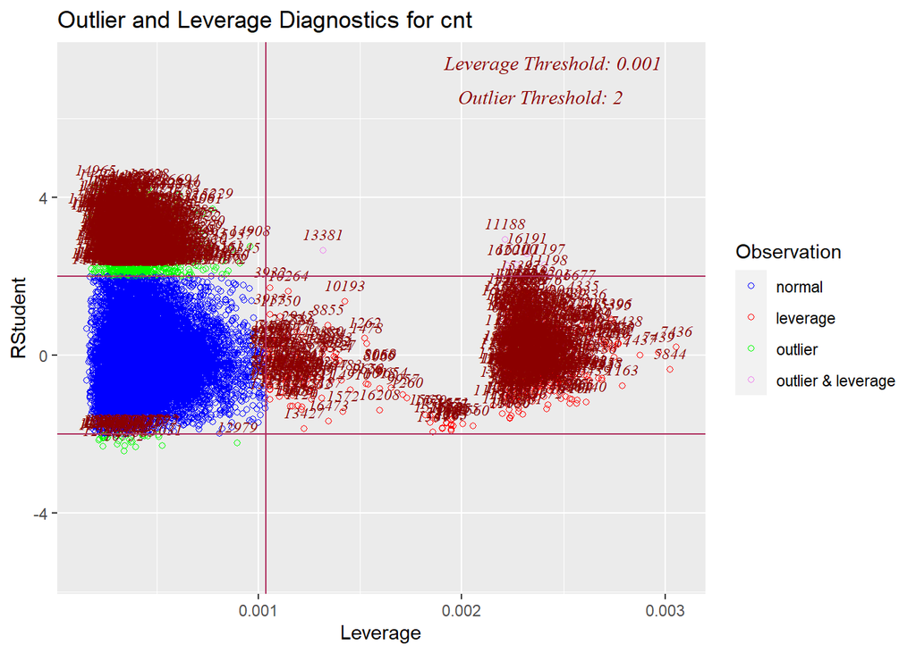

```r
# Fit the linear regression model
bikemod <- lm(cnt ~ season + weekday + holiday + atemp
          + hum + windspeed + yr + weathersit, data = bike)

# Plot residual vs. leverage
ols_plot_resid_lev(bikemod)
```

```r
# Identify influential observations based on the diagnostic plots
outliers <- which(abs(cooks.distance(bikemod)) > 4 / length(fitted(bikemod)))

# Remove outliers from the dataset
bike_clean <- bike[-outliers, ]
```

```r
# Refit the model with the cleaned dataset
bikemod_clean <- lm(cnt ~ season + weekday + holiday + atemp + hum + windspeed + yr + weathersit, data = bike_clean)
summary(bikemod_clean)
```

```
##
## Call:
## lm(formula = cnt ~ season + weekday + holiday + atemp + hum +
##     windspeed + yr + weathersit, data = bike_clean)
##
## Residuals:
##     Min      1Q  Median      3Q     Max
## -332.41  -84.20  -18.95   64.98  475.45
##
## Coefficients:
##              Estimate Std. Error t value Pr(>|t|)
## (Intercept)   96.4730     5.7006  16.923  < 2e-16 ***
## season        15.9087     0.9434  16.864  < 2e-16 ***
## weekday        1.6685     0.4811   3.468 0.000526 ***
## holiday      -24.3963     6.3576  -3.837 0.000125 ***
## atemp        336.5847     6.0025  56.074  < 2e-16 ***
## hum         -285.3699     6.0357 -47.280  < 2e-16 ***
## windspeed     67.1698     8.5031   7.899 2.98e-15 ***
## yr            49.8056     1.9430  25.633  < 2e-16 ***
## weathersit     9.4888     1.7186   5.521 3.41e-08 ***
## ---
## Signif. codes:  0 '***' 0.001 '**' 0.01 '*' 0.05 '.' 0.1 ' ' 1
##
## Residual standard error: 124.5 on 16586 degrees of freedom
## Multiple R-squared:  0.3451, Adjusted R-squared:  0.3448
## F-statistic:  1092 on 8 and 16586 DF,  p-value: < 2.2e-16
```

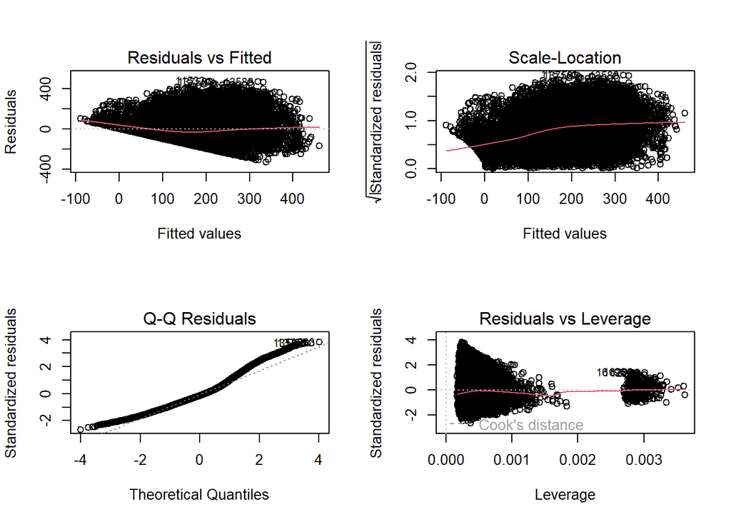

```r
layout(matrix(1:4,2,2)) # plotting all four graphs at once
plot(bikemod_clean)
```

### Graph 1.

In the residual vs. fitted plot, while most residuals align closely around 0, indicating a good fit, a downward slope in the lower half of the data points suggests potential issues with the model’s predictive accuracy, especially for higher values of the response variable.One possible way to improve upon this would be a stricter removal of outliers.

### Graph 3.

The Q-Q plot reveals a predominantly straight line, indicating that the residuals adhere closely to a distribution that is approximately normal across most of the data range. However, a slight rise towards the end of the plot suggests deviations from normality, particularly at the upper end of the residual distribution.

While the normality assumption is reasonably met for the majority of the data, the presence of deviations at the upper end indicates potential outliers or influential observations that may impact the validity of the regression analysis.

# Splitting the Data

## Divide the data into training and test sets.

The clean bike dataset is divided into two subsets: a training set and a test set to train the regression model and evaluate the model’s performance.The data has to be split so the model can learn from unseen data and ensure it is evaluated with an unbiased accuracy rate.

```r
set.seed(123)
training.samples <- bike_clean$cnt %>%
  createDataPartition(p = 0.8, list = FALSE)
train.data <- bike_clean[training.samples, ]
test.data <- bike_clean[-training.samples, ]
dim(train.data)
```

```
## [1] 13278    17
```

```r
dim(test.data)
```

```
## [1] 3317   17
```

## Creating the Regression Model

The model is created and trained using the training set.

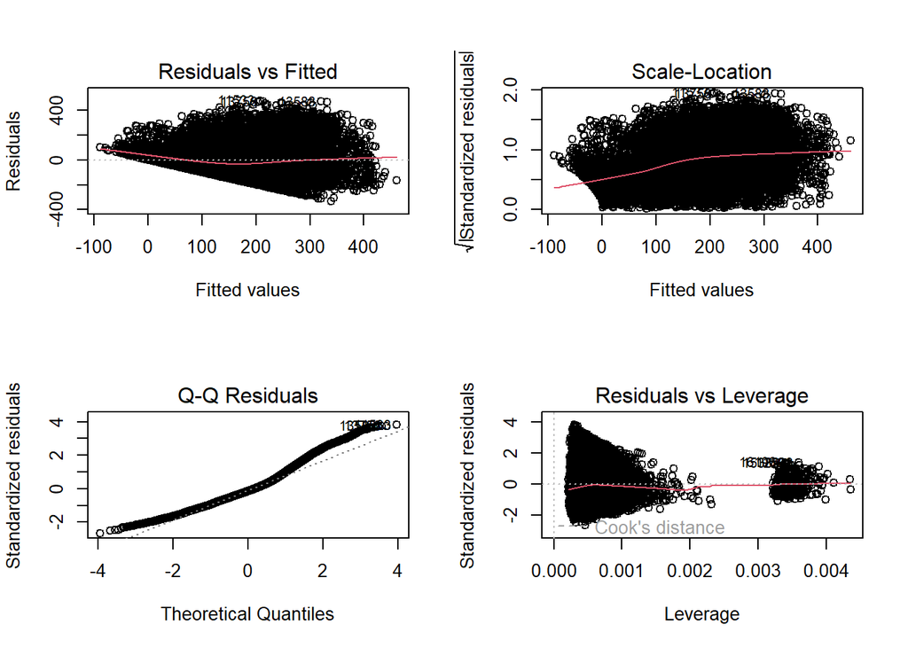

```r
bikemodel <- lm(cnt ~ season + weekday + holiday + atemp
          + hum + windspeed + yr + weathersit,
                train.data)
summary(bikemodel)
# Plot Residuals
layout(matrix(1:4,2,2))
plot(bikemodel)
```

## Coefficient of Determination

The proportion of variance is measured using *summary()$rsquared*. A higher r-squared is desiriable in regression models, as more of the unknown is explained by the model’s predictor variables themselves proving a strong relationship between the predictor variables and the independent variable.

```r
# rsquared shows how much variance is explained by the model
summary(bikemodel)$r.squared
```

```
## [1] 0.345785
```

```r
summary(bikemodel)
```

```
##
## Call:
## lm(formula = cnt ~ season + weekday + holiday + atemp + hum +
##     windspeed + yr + weathersit, data = train.data)
##
## Residuals:
##     Min      1Q  Median      3Q     Max
## -332.93  -84.18  -18.83   64.53  475.30
##
## Coefficients:
##              Estimate Std. Error t value Pr(>|t|)
## (Intercept)   96.2567     6.3621  15.130  < 2e-16 ***
## season        15.9488     1.0525  15.153  < 2e-16 ***
## weekday        1.5929     0.5375   2.963 0.003047 **
## holiday      -24.5579     6.9274  -3.545 0.000394 ***
## atemp        335.1251     6.6903  50.091  < 2e-16 ***
## hum         -286.8578     6.7415 -42.551  < 2e-16 ***
## windspeed     68.9121     9.5124   7.244 4.58e-13 ***
## yr            51.0923     2.1715  23.529  < 2e-16 ***
## weathersit     9.9458     1.9200   5.180 2.25e-07 ***
## ---
## Signif. codes:  0 '***' 0.001 '**' 0.01 '*' 0.05 '.' 0.1 ' ' 1
##
## Residual standard error: 124.5 on 13269 degrees of freedom
## Multiple R-squared:  0.3458, Adjusted R-squared:  0.3454
## F-statistic: 876.7 on 8 and 13269 DF,  p-value: < 2.2e-16
```

The p-value is less than .05; therefore, we reject the null hypothesis indicating there is no relationship between the variables. There is a significant relationship between the variables in the model.

# Making Predictions

Here, the trained regression model is employed to predict the independent variable *cnt* using the test data created previously.

```r
predictions <- predict(bikemodel, test.data)
head(predictions)
```

```
##         4         7        22        31        34        38
## 13.047656 -6.389135 42.556615 64.553785 31.962784 54.190991
```

## Prediction Performance

The Mean Absolute Error(MAE), Root Mean Squared Error(RMSE) and Mean Absolute Percentage Error(MAPE) are used to evaluate the accuracy of the model in it’s predictions.

```r
MAE(predictions, test.data$cnt)
```

```
## [1] 96.76409
```

```r
RMSE(predictions, test.data$cnt)
```

```
## [1] 124.5166
```

```r
MAPE(predictions, test.data$cnt) # Lower values are desirable, indicating better accuracy
```

```
## [1] 4.161234
```

## Data Visualisation

### Confidence Interval and Prediction Interval Displays

A confidence interval specifies the range of values within which a certain level of confidence expects the true outcome to lie. The prediction interval provides an understanding of the uncertainty associated with individual future observations. Here, a confidence interval plot and prediction interval plot is generated visualising the model’s predictions.

```r
confidence_predictions <- predict(bikemodel, test.data, interval="confidence")
head(confidence_predictions)
```

```
##          fit        lwr        upr
## 4  13.047656   6.124407 19.9709052
## 7  -6.389135 -13.521374  0.7431033
## 22 42.556615  36.445485 48.6677448
## 31 64.553785  58.884333 70.2232377
## 34 31.962784  26.126874 37.7986934
## 38 54.190991  46.737817 61.6441650
```

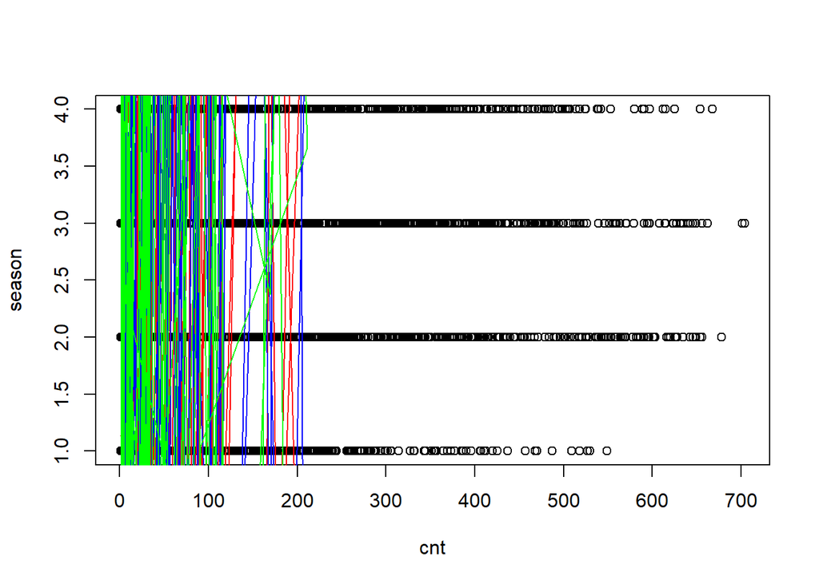

```r
plot(season~cnt, data=test.data)
lines(test.data$cnt,confidence_predictions[,1],col="red") # lower bound
lines(test.data$cnt,confidence_predictions[,2],col="blue") # predictions
lines(test.data$cnt,confidence_predictions[,3],col="green") # upper
```

### Generate Plots Showing the Prediction Interval

```r
predict_predictions <- predict(bikemodel, test.data, interval="predict")
head(predict_predictions)
```

```
##          fit       lwr      upr
## 4  13.047656 -231.0070 257.1023
## 7  -6.389135 -250.4498 237.6716
## 22 42.556615 -201.4764 286.5896
## 31 64.553785 -179.4686 308.5761
## 34 31.962784 -212.0635 275.9890
## 38 54.190991 -189.8793 298.2613
```

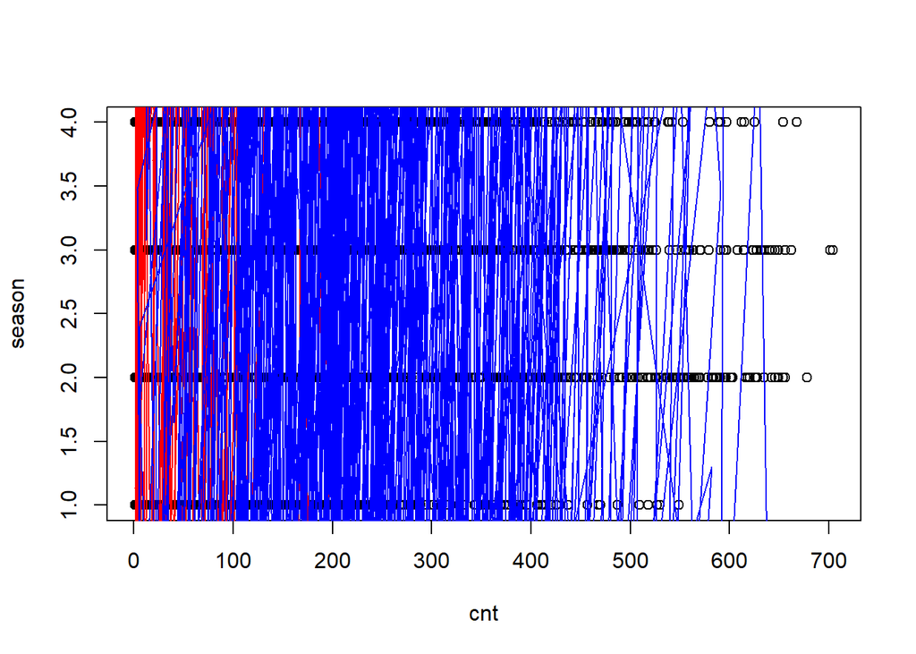

```r
plot(season~cnt, data=test.data)
lines(test.data$cnt,predict_predictions[,1],col="red")
lines(test.data$cnt,predict_predictions[,2],col="blue")
lines(test.data$cnt,predict_predictions[,3],col="green")
```

## Custom Predictions with the Model

This section illustrates how the trained regression model can be utilised to predict outcomes for new, customised scenarios involving unseen data. Once a model has a greater r-squared figure and more precise accuracy rate, It can assist in decision-making problems in real-life capacities.

```r
bikedf<- data.frame(season = 1, weekday = 0, holiday = 0, atemp = 20, hum = 13, windspeed = 30, yr = 2011, weathersit = 1)
predict_predictions<-predict(bikemodel, bikedf, interval="predict")
predict_predictions
```

```
##        fit      lwr    upr
## 1 107909.4 99291.84 116527
```

## Conclusion

This project delved into analysing bike rental data using multiple linear regression with RMarkdown. While I had some initial hurdles revisiting RMarkdown after a break, refreshing myself with official RStudio resources and user guides proved valuable. However, incorporating references using RMarkdown presented a new challenge. The limited online resources on this topic (especially visual or descriptive ones) this area a bit stressful. Thankfully, I was able to leverage the academic referencing tool Zotero to complete the citations.

Overall, the analysis yielded valuable insights into the factors affecting bike rental counts. It began with a thorough exploration of the data to ensure its quality and understandability. Through iterative model fitting and refinement, key predictors emerged – seasonality, weather, day of the week, and year – all of which significantly influence bike rental demand.

This analysis offers valuable takeaways for bike rental businesses, enabling them to enhance operations, predict demand fluctuations, and improve customer satisfaction. By leveraging regression analysis to anticipate trends and continually refine the models, stakeholders can make informed decisions to effectively meet the evolving needs of bike rental users.

## References

“Regression Analysis” (n.d.) “Rmarkdown.pdf” (n.d.) “Linear Regression Plots: Fitted Vs Residuals – Boostedml” (2019) “How to Interpret a Residual Plot | Algebra” (n.d.) Frost (2017) Lantz (2013)

Frost, Jim. 2017. “How to Interpret P-Values and Coefficients in Regression Analysis.” Statistics By Jim. April 12, 2017. http://statisticsbyjim.com/regression/interpret-coefficients-p-values-regression/.

“How to Interpret a Residual Plot | Algebra.” n.d. Study.com. Accessed April 3, 2024. https://study.com/skill/learn/how-to-interpret-a-residual-plot-explanation.html.

Lantz, Brett. 2013. *Machine Learning with R. [Electronic Resource]*. Packt Publishing.

“Linear Regression Plots: Fitted Vs Residuals – Boostedml.” 2019. March 27, 2019. https://boostedml.com/2019/03/linear-regression-plots-fitted-vs-residuals.html.

“Regression Analysis.” n.d. Statistics By Jim. Accessed February 27, 2024. http://statisticsbyjim.com/glossary/regression-analysis/.

“Rmarkdown.pdf.” n.d. Accessed April 3, 2024. https://raw.githubusercontent.com/rstudio/cheatsheets/main/rmarkdown.pdf.